# Briana Maximino | Marketing Portfolio

Marketing Management Student | Brand Strategy | Digital Marketing | Marketing Analytics

# Briana Maximino

## Marketing Management Student at Cal Poly Pomona

Hi, my name is Briana Maximino, and I am a Business Administration student at Cal Poly Pomona with a concentration in Marketing Management.

I am interested in sports marketing, brand strategy, digital marketing, and marketing analytics. This portfolio highlights my ability to create marketing campaigns, analyze data, build dashboards, and present professional project findings using tools such as Quarto, R, Excel, Google Analytics, and GitHub Pages.

My goal is to continue building experience in marketing roles where I can combine creativity, data, and strategy to better understand audiences and improve campaign performance.

View Projects View Resume [LinkedIn](https://www.linkedin.com/in/brianamaximino)

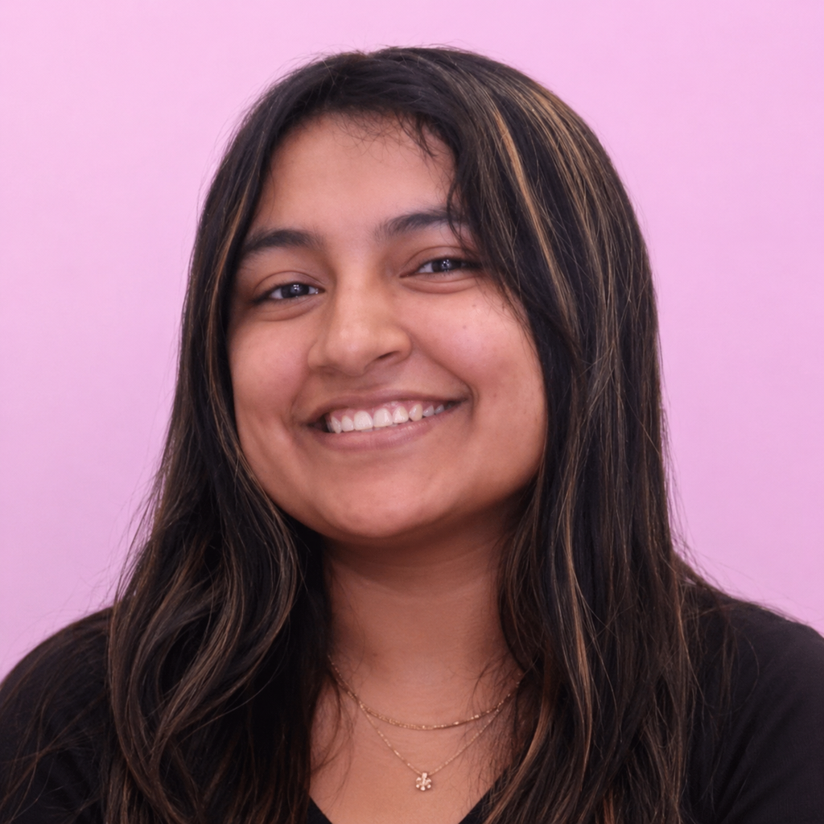

## Career Focus

I am building a career path in marketing with a strong interest in sports marketing, brand strategy, campaign planning, and marketing analytics. I enjoy understanding what audiences care about and using that information to create better marketing ideas, stronger messages, and more effective campaigns.

My portfolio is designed for prospective employers, recruiters, and professors who want to see my marketing work, technical skills, and professional growth.

## Education

**California State Polytechnic University, Pomona**  
Bachelor of Science in Business Administration  
Concentration: Marketing Management

My coursework has helped me build a foundation in marketing research, consumer behavior, digital marketing, business strategy, analytics, and professional communication.

## Featured Skills

### Marketing Strategy

- Brand positioning
- Campaign planning
- Target audience analysis
- Consumer behavior
- Sports marketing concepts

### Marketing Analytics

- Data visualization
- Dashboard building
- Google Analytics
- Excel
- R programming

### Digital Portfolio Tools

- Quarto
- GitHub Pages
- Revealjs presentations
- HTML
- CSS

## Featured Work

### Marketing Projects

My marketing projects showcase campaign planning, brand strategy, audience targeting, and creative marketing execution.

View Marketing Projects

### Marketing Analytics

My analytics work highlights data-driven thinking through visualizations, dashboards, and performance-focused insights.

View Marketing Analytics

### Dashboard

My dashboard section demonstrates how marketing information can be organized and visualized to support better decisions.

View Dashboard

## Highlighted Projects

### Super Soakerz Marketing Campaign

Super Soakerz was a student-led car window washing business created as part of a marketing course at Cal Poly Pomona. The project focused on building a service brand, promoting it to students, and evaluating customer response.

**Skills shown:** campaign planning, campus marketing, branding, customer targeting, and promotional strategy.

View Super Soakerz Project

### LA Galaxy Mock Campaign

This project connects to my interest in sports marketing by focusing on fan engagement, younger audiences, and campaign ideas that could strengthen brand connection.

**Skills shown:** sports marketing, audience segmentation, campaign messaging, and digital promotion.

View LA Galaxy Campaign

### Tesla Corporate Strategy Analysis

This project analyzes Tesla’s brand strategy, innovation, sustainability messaging, and competitive positioning.

**Skills shown:** brand analysis, corporate strategy, research, and marketing insight.

View Tesla Analysis

## Presentation

This section showcases my Revealjs presentation created with Quarto. It demonstrates my ability to organize marketing ideas and present information in a polished digital format.

View Featured Work

## Google Analytics

This website is connected to Google Analytics to track visitor activity and understand how users interact with my portfolio.

Google Analytics helps me connect my interest in marketing analytics to a real digital platform by showing how website traffic, page views, and engagement can be measured.

View Google Analytics Page

## Resume and Contact

I am currently seeking opportunities where I can continue growing my skills in marketing, brand strategy, sports marketing, and analytics.

View Resume

## Portfolio Purpose

This portfolio was created using Quarto and GitHub Pages as part of my Marketing Analytics coursework. It is also designed to serve as a professional portfolio that I can continue improving as I build more marketing experience, projects, and technical skills.